# Generalized Additive Models with Hyper Column

Tingting Zhan

# Introduction

This vignette of documents applications based on package **`hyper.gam`** ([Github](https://github.com/tingtingzhan/hyper.gam), [RPubs](https://rpubs.com/tingtingzhan/hyper_gam)).

## Prerequisite

New features are first implemented on [Github](https://github.com/tingtingzhan/hyper.gam).

```r
devtools::install_github('tingtingzhan/hyper.gam')
```

And eventually make their way to [`CRAN`](https://CRAN.R-project.org/package=hyper.gam).

```r
utils::install.packages('hyper.gam')
```

## Getting Started

Examples in this vignette require that the `search` path has

```r
library(hyper.gam)
library(survival)
```

## Terms and Abbreviations

| Term / Abbreviation | Description | Reference |
| --- | --- | --- |
|  | Forward pipe operator | `?base::pipeOp` introduced in `R` 4.1.0 |
| `attr` | Attributes | `base::attr`; `base::attributes` |
| `contour` | Contours | `graphics::contour`; `hyper.gam::contour.hyper_gam` |
| `coxph` | Cox model | `survival::coxph` |
| `gam` | Generalized additive models | `mgcv::gam` |
| `groupedHyperframe`, `hypercolumn` | (Hyper column of) (grouped) hyper data frame | `groupedHyperframe::as.groupedHyperframe`; `spatstat.geom::hyperframe` |
| `htmlwidget` | HTML Widgets | `` ?htmlwidgets::`htmlwidgets-package` ``; `plotly::plotly` |
| `persp` | Perspective plot | `graphics::persp`; `hyper.gam::persp.hyper_gam` |
| `PFS` | Progression/recurrence free survival | https://en.wikipedia.org/wiki/Progression-free_survival |
| `quantile` | Quantile | `stats::quantile` |
| `S3`, `generic`, `methods` | `S3` object oriented system | `base::UseMethod`; `utils::methods`; `utils::getS3method`; https://adv-r.hadley.nz/s3.html |
| `Surv` | Survival object | `survival::Surv` |

## Acknowledgement

The authors thank [Erjia Cui](https://orcid.org/0000-0003-3576-2892) for his contribution to function `hyper_gam()`.

This work is supported by NCI R01CA222847 ([I. Chervoneva](https://orcid.org/0000-0002-9104-4505), [T. Zhan](https://orcid.org/0000-0001-9971-4844), and [H. Rui](https://orcid.org/0000-0002-8778-261X)) and R01CA253977 (H. Rui and I. Chervoneva).

# Quantile Index Predictor

Publications include (Yi et al. 2023b, 2023a).

## Data Preparation

Data set `groupedHyperframe::Ki67` is a `groupedHyperframe` with a `numeric`-`hypercolumn` *`logKi67`* and a nested grouping structure *`~patientID/tissueID`*

```r
data(Ki67, package = 'groupedHyperframe')
Ki67
```

```
Grouped Hyperframe: ~patientID/tissueID

645 tissueID nested in
622 patientID

Preview of first 10 (or less) rows:

     logKi67 tissueID Tstage  PFS recfreesurv_mon recurrence adj_rad adj_chemo
1  (numeric) TJUe_I17      2 100+             100          0   FALSE     FALSE
2  (numeric) TJUe_G17      1   22              22          1   FALSE     FALSE
3  (numeric) TJUe_F17      1  99+              99          0   FALSE        NA
4  (numeric) TJUe_D17      1  99+              99          0   FALSE      TRUE
5  (numeric) TJUe_J18      1  112             112          1    TRUE      TRUE
6  (numeric) TJUe_N17      4   12              12          1    TRUE     FALSE
7  (numeric) TJUe_J17      2  64+              64          0   FALSE     FALSE
8  (numeric) TJUe_F19      2  56+              56          0   FALSE     FALSE
9  (numeric) TJUe_P19      2  79+              79          0   FALSE     FALSE
10 (numeric) TJUe_O19      2   26              26          1   FALSE      TRUE
   histology  Her2   HR  node  race age patientID
1          3  TRUE TRUE  TRUE White  66   PT00037
2          3 FALSE TRUE FALSE Black  42   PT00039
3          3 FALSE TRUE FALSE White  60   PT00040
4          3 FALSE TRUE  TRUE White  53   PT00042
5          3 FALSE TRUE  TRUE White  52   PT00054
6          2  TRUE TRUE  TRUE Black  51   PT00059
7          3 FALSE TRUE  TRUE Asian  50   PT00062
8          2  TRUE TRUE  TRUE White  37   PT00068
9          3  TRUE TRUE FALSE White  68   PT00082
10         2  TRUE TRUE FALSE Black  55   PT00084
```

Analysis in the next section is based on the aggregated quantiles by `patientID`. Users are encouraged to learn more about the `groupedHyperframe` class and the function `aggregate_quantile()` from package **`groupedHyperframe`** [vignettes](https://rpubs.com/tingtingzhan/groupedHyperframe).

```r
s = Ki67 |>
  aggregate_quantile(by = ~ patientID, probs = seq.int(from = .01, to = .99, by = .01))
s |> head()
```

```
Hyperframe:
  Tstage  PFS recfreesurv_mon recurrence adj_rad adj_chemo histology  Her2   HR
1      2 100+             100          0   FALSE     FALSE         3  TRUE TRUE
2      1   22              22          1   FALSE     FALSE         3 FALSE TRUE
3      1  99+              99          0   FALSE        NA         3 FALSE TRUE
4      1  99+              99          0   FALSE      TRUE         3 FALSE TRUE
5      1  112             112          1    TRUE      TRUE         3 FALSE TRUE
6      4   12              12          1    TRUE     FALSE         2  TRUE TRUE
   node  race age patientID logKi67.quantile
1  TRUE White  66   PT00037        (numeric)
2 FALSE Black  42   PT00039        (numeric)
3 FALSE White  60   PT00040        (numeric)
4  TRUE White  53   PT00042        (numeric)
5  TRUE White  52   PT00054        (numeric)
6  TRUE Black  51   PT00059        (numeric)
```

## Linear Quantile Index

We fit a linear `hyper_gam` model, i.e., a `gam` model with the `numeric`-`hypercolumn` *`logKi67.quantile`* using `mgcv::s` smooth.

```r
m0 = hyper_gam(PFS ~ logKi67.quantile, data = s)
```

### Visualization

Function `integrandSurface()` creates an interactive `htmlwidget` by package **`plotly`** to illustrate the integrand surface of linear quantile indices $p\in[0,1]$ and $q\in\text{range}\big(Q_i(p)\big)$ for all subjects $i=1,\cdots,n$.

$$\hat{S}_0(p,q) = \hat{\beta}(p)\cdot q$$

as well as the projections of the integrand curves of selected subjects onto the $(p,q)$- and $(S,p)$-plane. Note that this `htmlwidget` is suppressed in the vignette on `CRAN` due to package size limit. This `htmlwidget` can be viewed and interacted with on [RPubs](https://rpubs.com/tingtingzhan/QuantileIndex).

```r
integrandSurface(m0)
```

Less fancy illustrations of the integrand surface include `persp`ective and `contour` plots provided by package **`graphics`** shipped with vanilla **`R`**.

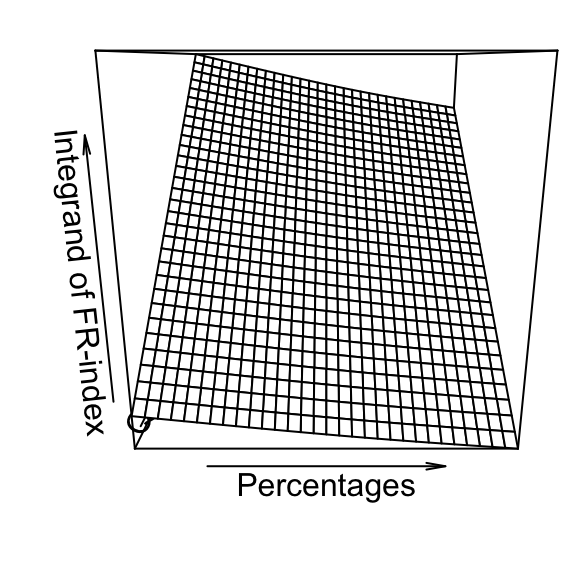

```r
par(mar = c(2, 2, 0, 0))
persp(m0)
```

```r
par(op)
```

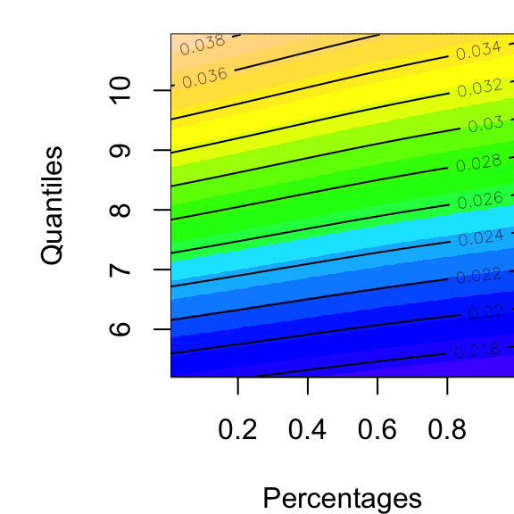

```r
par(mar = c(4, 5, 1, 0))
contour(m0)
```

```r
par(op)
```

### $k$-Fold Prediction

Linear quantile index is the $k$-fold prediction of the linear `hyper_gam` model *`m0`*.

```r
set.seed(145); QI = m0 |>
  kfoldPredict.hyper_gam(k = 10L, mc.cores = 1L)
```

Diagnosis of linear quantile index *`QI`*

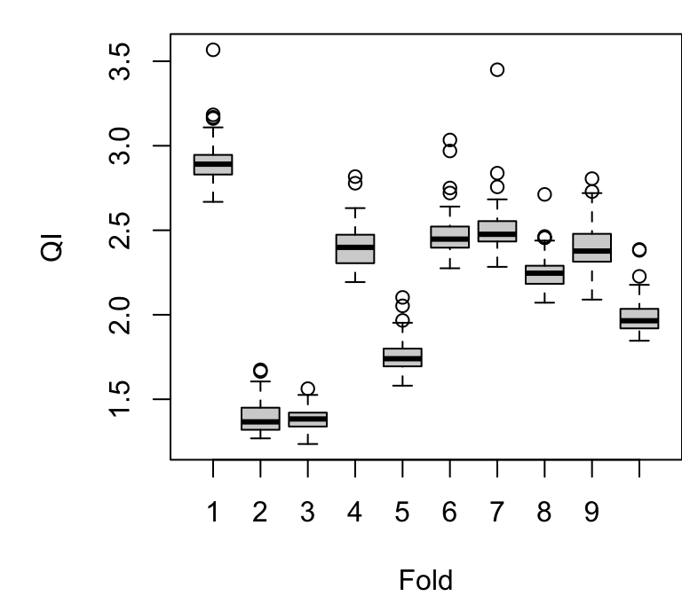

```r
par(mar = c(4, 5, 1, 0))
boxplot(QI ~ attr(QI, 'fold'), xlab = 'Fold')
```

```r
par(op)
```

### Regression Model using Linear Quantile Index

```r
suppressWarnings(sQI <- cbind(s, spatstat.geom::hyperframe(QI = QI)) |>
                   as.data.frame())
coxph(PFS ~ QI, data = sQI) |> summary()
```

```
Call:
coxph(formula = PFS ~ QI, data = sQI)

  n= 622, number of events= 118

      coef exp(coef) se(coef)    z Pr(>|z|)
QI 0.07052   1.07306  0.18550 0.38    0.704

   exp(coef) exp(-coef) lower .95 upper .95
QI     1.073     0.9319     0.746     1.544

Concordance= 0.514  (se = 0.027 )
Likelihood ratio test= 0.14  on 1 df,   p=0.7
Wald test            = 0.14  on 1 df,   p=0.7
Score (logrank) test = 0.14  on 1 df,   p=0.7
```

## Nonlinear Quantile Index

We fit a nonlinear `hyper_gam` model, i.e., a `gam` model with the `numeric`-`hypercolumn` *`logKi67.quantile`* using tensor product interaction `mgcv::ti` smooth.

```r
m1 = hyper_gam(PFS ~ logKi67.quantile, data = s, nonlinear = TRUE)
```

### Visualization

Function `integrandSurface()` illustrates the integrand surface of nonlinear quantile indices $p\in[0,1]$ and $q\in\text{range}\big(Q_i(p)\big)$ for all subjects $i=1,\cdots,n$.

$$\hat{S}_0(p,q) = \hat{F}(p,q)$$
as well as the projections of the integrand curves of selected subjects onto the $(p,q)$- and $(S,p)$-plane. Note that this `htmlwidget` is suppressed in the vignette on `CRAN` due to package size limit. This `htmlwidget` can be viewed and interacted with on [RPubs](https://rpubs.com/tingtingzhan/QuantileIndex).

```r
integrandSurface(m1)
```

Less fancy illustrations of the integrand surface include `persp`ective and `contour` plots provided by package **`graphics`** shipped with vanilla **`R`**.

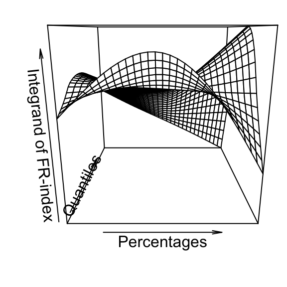

```r
par(mar = c(2, 2, 0, 0))
persp(m1)
```

```r
par(op)
```

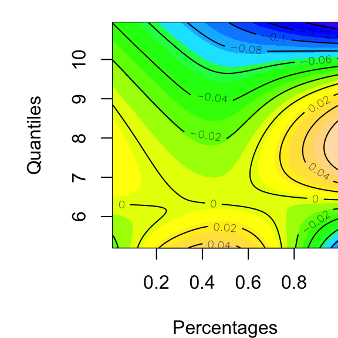

```r
par(mar = c(4, 5, 1, 0))
contour(m1)
```

```r
par(op)
```

### $k$-Fold Prediction

Nonlinear quantile index is the $k$-fold prediction of the nonlinear `hyper_gam` model *`m1`*.

```r
set.seed(145); nlQI = m1 |> kfoldPredict.hyper_gam(k = 10L, mc.cores = 1L)
```

Diagnosis of nonlinear quantile index *`nlQI`*.

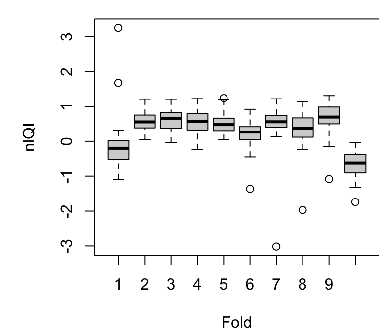

```r
par(mar = c(4, 5, 1, 0))
boxplot(nlQI ~ attr(nlQI, 'fold'), xlab = 'Fold')
```

```r
par(op)
```

```r
suppressWarnings(s_nlQI <- cbind(s, spatstat.geom::hyperframe(nlQI = nlQI)) |>
                   as.data.frame())
coxph(PFS ~ nlQI, data = s_nlQI) |> summary()
```

```
Call:
coxph(formula = PFS ~ nlQI, data = s_nlQI)

  n= 622, number of events= 118

       coef exp(coef) se(coef)    z Pr(>|z|)
nlQI 0.0735    1.0763   0.1669 0.44     0.66

     exp(coef) exp(-coef) lower .95 upper .95
nlQI     1.076     0.9291    0.7759     1.493

Concordance= 0.527  (se = 0.029 )
Likelihood ratio test= 0.2  on 1 df,   p=0.7
Wald test            = 0.19  on 1 df,   p=0.7
Score (logrank) test = 0.19  on 1 df,   p=0.7
```

# References

Yi, Misung, Tingting Zhan, Amy R. Peck, Jeffrey A. Hooke, Albert J. Kovatich, Craig D. Shriver, Hai Hu, Yunguang Sun, Hallgeir Rui, and Inna Chervoneva. 2023a. “Quantile Index Biomarkers Based on Single-Cell Expression Data.” *Laboratory Investigation* 103 (8): 100158. https://doi.org/10.1016/j.labinv.2023.100158.

———. 2023b. “Selection of Optimal Quantile Protein Biomarkers Based on Cell-Level Immunohistochemistry Data.” *BMC Bioinformatics* 24 (1): 298. https://doi.org/10.1186/s12859-023-05408-8.